# Lecture 18

2026-05-28

# Factors (from Lecture 16)

## What are Factors?

- Factors are variables in R which take on a limited number of different values, typically they are called non-numerical or “categorical” variables.
- We use factors in statistical modeling because non-numerical variables (e.g., ancestry — African, Asian, European, Other) enter into statistical models differently than numerical variables.
- Designating non-numerical data as factors insures that the modeling functions in R will treat these types of variables correctly.

## Underneath a Factor

- Factors in R are stored as a vector of integer values mapped to a corresponding set of character values. The character values are actually what gets displayed.
- This is an efficient way to store character values, because each character value is stored only one time, and the data values are stored as a vector of integers. This requires far fewer computing resources.
- This mechanism behind R’s factors and an AI’s chat window is the same: mapping human-readable text to machine-readable integers using a lookup dictionary.

## Take a look at Factors

```r
print(paste("variable Species in iris is a:", class(iris$Species)))
```

```
[1] "variable Species in iris is a: factor"
```

```r
print(levels(iris$Species))
```

```
[1] "setosa"     "versicolor" "virginica"
```

```r
print(as.numeric(iris$Species))
```

```
  [1] 1 1 1 1 1 1 1 1 1 1 1 1 1 1 1 1 1 1 1 1 1 1 1 1 1 1 1 1 1 1 1 1 1 1 1 1 1
 [38] 1 1 1 1 1 1 1 1 1 1 1 1 1 2 2 2 2 2 2 2 2 2 2 2 2 2 2 2 2 2 2 2 2 2 2 2 2
 [75] 2 2 2 2 2 2 2 2 2 2 2 2 2 2 2 2 2 2 2 2 2 2 2 2 2 2 3 3 3 3 3 3 3 3 3 3 3
[112] 3 3 3 3 3 3 3 3 3 3 3 3 3 3 3 3 3 3 3 3 3 3 3 3 3 3 3 3 3 3 3 3 3 3 3 3 3
[149] 3 3
```

## Bivariate Iris

```r
model1 <- lm(iris$Petal.Length ~ iris$Sepal.Length)
summary(model1)
```

```
Call:
lm(formula = iris$Petal.Length ~ iris$Sepal.Length)

Residuals:
     Min       1Q   Median       3Q      Max
-2.47747 -0.59072 -0.00668  0.60484  2.49512

Coefficients:
                  Estimate Std. Error t value Pr(>|t|)
(Intercept)       -7.10144    0.50666  -14.02   <2e-16 ***
iris$Sepal.Length  1.85843    0.08586   21.65   <2e-16 ***
---
Signif. codes:  0 '***' 0.001 '**' 0.01 '*' 0.05 '.' 0.1 ' ' 1

Residual standard error: 0.8678 on 148 degrees of freedom
Multiple R-squared:   0.76, Adjusted R-squared:  0.7583
F-statistic: 468.6 on 1 and 148 DF,  p-value: < 2.2e-16
```

## Multiple Regression Iris with Factor

```r
model2 <- lm(iris$Petal.Length ~ iris$Sepal.Length + iris$Species)
summary(model2)
```

```
Call:
lm(formula = iris$Petal.Length ~ iris$Sepal.Length + iris$Species)

Residuals:
     Min       1Q   Median       3Q      Max
-0.76390 -0.17875  0.00716  0.17461  0.79954

Coefficients:
                       Estimate Std. Error t value Pr(>|t|)
(Intercept)            -1.70234    0.23013  -7.397 1.01e-11 ***
iris$Sepal.Length       0.63211    0.04527  13.962  < 2e-16 ***
iris$Speciesversicolor  2.21014    0.07047  31.362  < 2e-16 ***
iris$Speciesvirginica   3.09000    0.09123  33.870  < 2e-16 ***
---
Signif. codes:  0 '***' 0.001 '**' 0.01 '*' 0.05 '.' 0.1 ' ' 1

Residual standard error: 0.2826 on 146 degrees of freedom
Multiple R-squared:  0.9749,    Adjusted R-squared:  0.9744
F-statistic:  1890 on 3 and 146 DF,  p-value: < 2.2e-16
```

## When bad things happen

- Factors can be troublesome if one doesn’t understand their behavior

```r
iris$Sepal_Width_FACTOR <- as.factor(iris$Sepal.Width)
levels(iris$Sepal_Width_FACTOR) # 23 levels representing the unique values
```

```
 [1] "2"   "2.2" "2.3" "2.4" "2.5" "2.6" "2.7" "2.8" "2.9" "3"   "3.1" "3.2"
[13] "3.3" "3.4" "3.5" "3.6" "3.7" "3.8" "3.9" "4"   "4.1" "4.2" "4.4"
```

```r
mean(iris$Sepal_Width_FACTOR) # error
```

```
[1] NA
```

```r
as.numeric(iris$Sepal_Width_FACTOR) |> mean() # some fix it this way, don't
```

```
[1] 10.57333
```

```r
mean(iris$Sepal.Width) # totall different
```

```
[1] 3.057333
```

```r
as.character(iris$Sepal_Width_FACTOR) |> as.numeric() |> mean() # this is clunky but works
```

```
[1] 3.057333
```

## Underneath the factor

```r
iris$Sepal_Width_to_numeric <- as.numeric(iris$Sepal_Width_FACTOR)
iris$Sepal_Width_to_character_numeric <- as.character(iris$Sepal_Width_FACTOR) |> as.numeric()
head(iris[, c(2, 6, 7, 8)], n = 50)
```

```
   Sepal.Width Sepal_Width_FACTOR Sepal_Width_to_numeric
1          3.5                3.5                     15
2          3.0                  3                     10
3          3.2                3.2                     12
4          3.1                3.1                     11
5          3.6                3.6                     16
6          3.9                3.9                     19
7          3.4                3.4                     14
8          3.4                3.4                     14
9          2.9                2.9                      9
10         3.1                3.1                     11
11         3.7                3.7                     17
12         3.4                3.4                     14
13         3.0                  3                     10
14         3.0                  3                     10
```

[output cut: 87 more lines]

## Usefulness of factors

- There exist `cut()` from base R and a variant in dplyr called `ntile()`
- If you understand factors after today, you might find these two useful.

```r
load("spotify_songs.RData")

## base R cut the values of variable into quartiles
pop_quartile <- cut(
      spotify_songs$track_popularity,
      breaks = quantile(spotify_songs$track_popularity, probs = seq(0, 1, 0.25)),
      include.lowest = TRUE
    )
is.factor(pop_quartile)
```

```
[1] TRUE
```

```r
## base R cut the values according to custom breaks

pop_custom <- cut(
    spotify_songs$track_popularity,
    breaks = c(0, 25, 50, 75, 100),
    include.lowest = TRUE
)
is.factor(pop_custom)
```

```
[1] TRUE
```

## visualized

- Notice, we are not required to table the factor values in base R

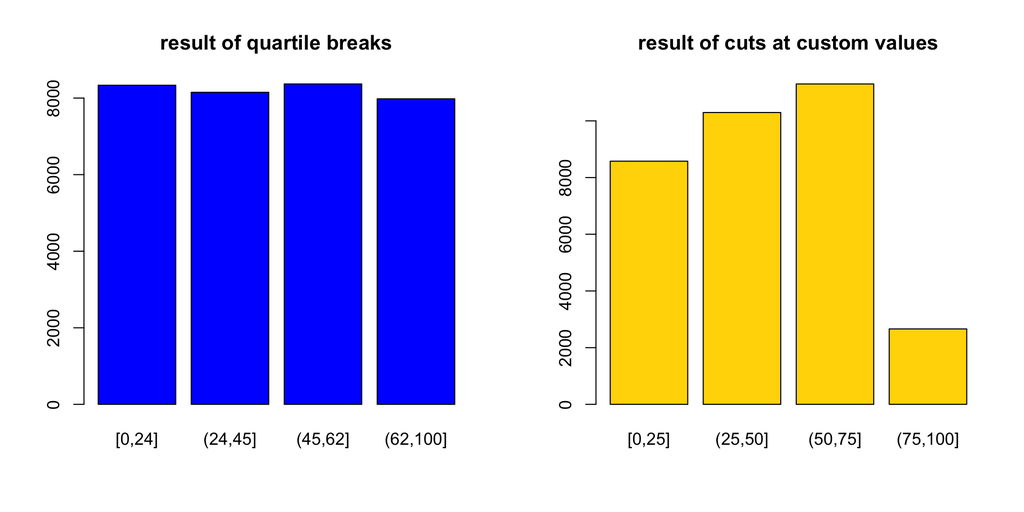

```r
old_par <- par(no.readonly = TRUE) # Save current settings
par(mfrow=c(1,2))
plot(pop_quartile, main="result of quartile breaks", col = "blue")
plot(pop_custom, main = "result of cuts at custom values", col = "gold")
```

```r
par(old_par) # Restore original settings
```

## compare dplyr ntile()

- `ntile()` is very exact, `cut()` can be sloppy and is better used if you do not need perfect balance

```r
library(dplyr)
pop_ntile <- ntile(spotify_songs$track_popularity, 4) # forces balance
is(pop_ntile) # not a factor
```

```
[1] "integer"             "double"              "numeric"
[4] "vector"              "data.frameRowLabels"
```

```r
table(pop_ntile)
```

```
pop_ntile
   1    2    3    4
8209 8208 8208 8208
```

## visualized

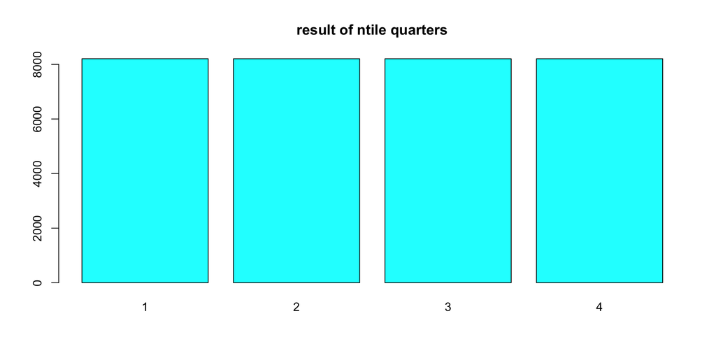

```r
barplot(table(pop_ntile), main = "result of ntile quarters", col = "cyan")
```

## Understanding

- Computers cannot do math on letters. So whether you are estimating a model in R in 101A or interacting with Claude/ChatGPT/etc., the system requires numbers to do its job.
- In R (Factors): If you have a column of survey data with “Low,” “Medium,” and “High,” R assigns integers to represent the values (e.g., 1, 2, 3). It then attaches a dictionary called `levels` to remember that 1 means “Low.” This mapping allows statistical algorithms (like regression) to perform calculations on categories.
- In AI (Tokenization): When you type a sentence into a chat window, the AI chops your words into chunks and assigns each chunk an ID number (e.g., “The” = 464, “cat” = 3432). It aslo uses a dictionary to remember what each number meant. This mapping allows the underlying models to perform linear algebra on your prompt.
- In both cases, integers are used as placeholder for a string to save memory and enable complex math.
- Of course they diverge tremendously: AI chunks words into fragments (e.g., “un” “remark” “able”) and the numeric values assigned to the fragments have no order. The dictionaries AI uses are also massive (e.g., 100,000 times larger than a factor’s levels in R)

## Additional Info regarding factors

- We can create factors using factor() BUT ALSO R can automatically designate variables as factors during certain types of data import or other forms of data reading.
- Both numeric and character variables can be converted into factors, but a factor’s values (known as levels) will always be displayed as character values - for example numbers will have quotes around them because they are being displayed as character
- So beware of numbers with quotes around them, it is a signal.

# Take a break (no attendance checking)

# One issue from earlier in the course: Sorting and Ordering

## Straight out of the documentation

Description

Sort (or order) a vector or factor (partially) into ascending or descending order. For ordering along more than one variable, e.g., for sorting data frames, see order.

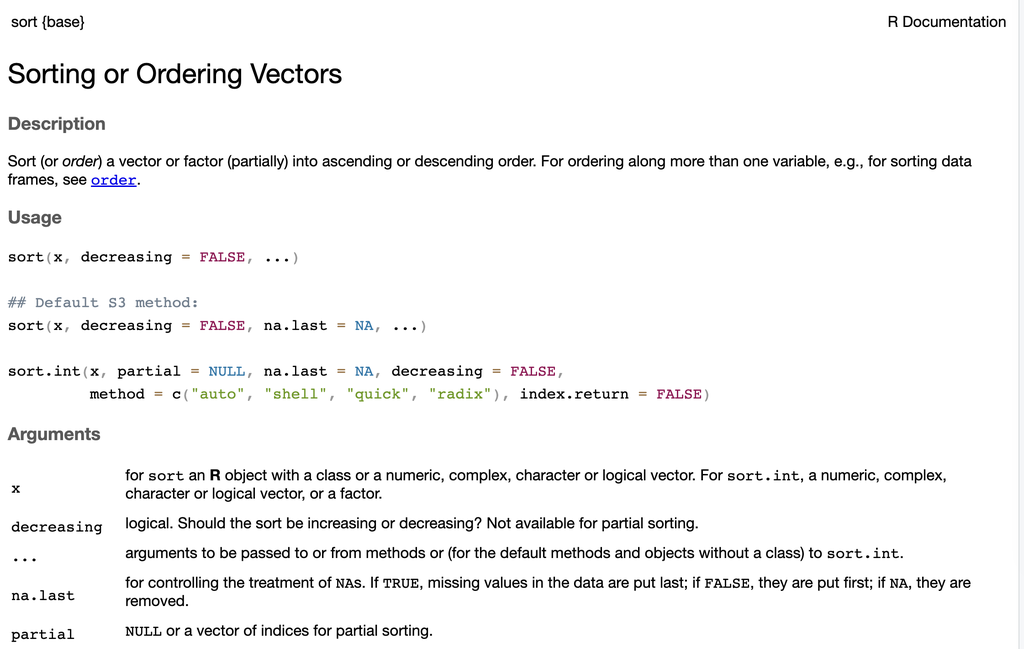

## sort() the values

Example

```r
x <- c(8, 6, 7, 5, 3, 0, 9)
x
```

```
[1] 8 6 7 5 3 0 9
```

### result of sort()

```r
sort(x)
```

```
[1] 0 3 5 6 7 8 9
```

if you need to save the results, you will need to assign the sort to an object, below x is not sorted because we didn’t save it sorted, we can also demonstrate a decreasing sort and save it to y:

```r
x
```

```
[1] 8 6 7 5 3 0 9
```

```r
y <- sort(x, decreasing = TRUE)
y
```

```
[1] 9 8 7 6 5 3 0
```

## Sorting Data Frames

What happens if you try to sort a data.frame column? Suppose you wanted to sort Sepal.Length in the data frame iris:

```r
sort(iris$Sepal.Length)
```

```
  [1] 4.3 4.4 4.4 4.4 4.5 4.6 4.6 4.6 4.6 4.7 4.7 4.8 4.8 4.8 4.8 4.8 4.9 4.9
 [19] 4.9 4.9 4.9 4.9 5.0 5.0 5.0 5.0 5.0 5.0 5.0 5.0 5.0 5.0 5.1 5.1 5.1 5.1
 [37] 5.1 5.1 5.1 5.1 5.1 5.2 5.2 5.2 5.2 5.3 5.4 5.4 5.4 5.4 5.4 5.4 5.5 5.5
 [55] 5.5 5.5 5.5 5.5 5.5 5.6 5.6 5.6 5.6 5.6 5.6 5.7 5.7 5.7 5.7 5.7 5.7 5.7
 [73] 5.7 5.8 5.8 5.8 5.8 5.8 5.8 5.8 5.9 5.9 5.9 6.0 6.0 6.0 6.0 6.0 6.0 6.1
 [91] 6.1 6.1 6.1 6.1 6.1 6.2 6.2 6.2 6.2 6.3 6.3 6.3 6.3 6.3 6.3 6.3 6.3 6.3
[109] 6.4 6.4 6.4 6.4 6.4 6.4 6.4 6.5 6.5 6.5 6.5 6.5 6.6 6.6 6.7 6.7 6.7 6.7
[127] 6.7 6.7 6.7 6.7 6.8 6.8 6.8 6.9 6.9 6.9 6.9 7.0 7.1 7.2 7.2 7.2 7.3 7.4
[145] 7.6 7.7 7.7 7.7 7.7 7.9
```

This is not too useful on its own. What happens when we try to sort the data frame, don’t do this:

```r
sort(iris)
```

```
Error in `xtfrm.data.frame()`:
! cannot xtfrm data frames
```

## order() is used to sort (rearrange) data frames

The next statement sorts iris on the basis of Sepal.Length and saves the re-ordered result to a new data frame:

```r
library(knitr)
iris2 <- iris[order(iris$Sepal.Length), ]
head(iris2) |>  kable()
```

|  | Sepal.Length | Sepal.Width | Petal.Length | Petal.Width | Species | Sepal_Width_FACTOR | Sepal_Width_to_numeric | Sepal_Width_to_character_numeric |
| --- | --- | --- | --- | --- | --- | --- | --- | --- |
| 14 | 4.3 | 3.0 | 1.1 | 0.1 | setosa | 3 | 10 | 3.0 |
| 9 | 4.4 | 2.9 | 1.4 | 0.2 | setosa | 2.9 | 9 | 2.9 |
| 39 | 4.4 | 3.0 | 1.3 | 0.2 | setosa | 3 | 10 | 3.0 |
| 43 | 4.4 | 3.2 | 1.3 | 0.2 | setosa | 3.2 | 12 | 3.2 |
| 42 | 4.5 | 2.3 | 1.3 | 0.3 | setosa | 2.3 | 3 | 2.3 |
| 4 | 4.6 | 3.1 | 1.5 | 0.2 | setosa | 3.1 | 11 | 3.1 |

## arrange in dplyr:

```r
library(dplyr)
iris %>% arrange(Sepal.Length) %>% head() %>% kable()
```

| Sepal.Length | Sepal.Width | Petal.Length | Petal.Width | Species | Sepal_Width_FACTOR | Sepal_Width_to_numeric | Sepal_Width_to_character_numeric |
| --- | --- | --- | --- | --- | --- | --- | --- |
| 4.3 | 3.0 | 1.1 | 0.1 | setosa | 3 | 10 | 3.0 |
| 4.4 | 2.9 | 1.4 | 0.2 | setosa | 2.9 | 9 | 2.9 |
| 4.4 | 3.0 | 1.3 | 0.2 | setosa | 3 | 10 | 3.0 |
| 4.4 | 3.2 | 1.3 | 0.2 | setosa | 3.2 | 12 | 3.2 |
| 4.5 | 2.3 | 1.3 | 0.3 | setosa | 2.3 | 3 | 2.3 |
| 4.6 | 3.1 | 1.5 | 0.2 | setosa | 3.1 | 11 | 3.1 |

## Decreasing sort()

We can also add decreasing=TRUE to order (base R with a pipe):

```r
iris3 <- iris2[order(iris2$Sepal.Length, decreasing = TRUE) , ]
head(iris3) |> kable()
```

|  | Sepal.Length | Sepal.Width | Petal.Length | Petal.Width | Species | Sepal_Width_FACTOR | Sepal_Width_to_numeric | Sepal_Width_to_character_numeric |
| --- | --- | --- | --- | --- | --- | --- | --- | --- |
| 132 | 7.9 | 3.8 | 6.4 | 2.0 | virginica | 3.8 | 18 | 3.8 |
| 118 | 7.7 | 3.8 | 6.7 | 2.2 | virginica | 3.8 | 18 | 3.8 |
| 119 | 7.7 | 2.6 | 6.9 | 2.3 | virginica | 2.6 | 6 | 2.6 |
| 123 | 7.7 | 2.8 | 6.7 | 2.0 | virginica | 2.8 | 8 | 2.8 |
| 136 | 7.7 | 3.0 | 6.1 | 2.3 | virginica | 3 | 10 | 3.0 |
| 106 | 7.6 | 3.0 | 6.6 | 2.1 | virginica | 3 | 10 | 3.0 |

## Decreasing arrange()

We can also add descending to arrange (the dplyr way):

```r
iris3 <- iris %>% arrange(desc(Sepal.Length))
head(iris3) %>% kable()
```

| Sepal.Length | Sepal.Width | Petal.Length | Petal.Width | Species | Sepal_Width_FACTOR | Sepal_Width_to_numeric | Sepal_Width_to_character_numeric |
| --- | --- | --- | --- | --- | --- | --- | --- |
| 7.9 | 3.8 | 6.4 | 2.0 | virginica | 3.8 | 18 | 3.8 |
| 7.7 | 3.8 | 6.7 | 2.2 | virginica | 3.8 | 18 | 3.8 |
| 7.7 | 2.6 | 6.9 | 2.3 | virginica | 2.6 | 6 | 2.6 |
| 7.7 | 2.8 | 6.7 | 2.0 | virginica | 2.8 | 8 | 2.8 |
| 7.7 | 3.0 | 6.1 | 2.3 | virginica | 3 | 10 | 3.0 |
| 7.6 | 3.0 | 6.6 | 2.1 | virginica | 3 | 10 | 3.0 |

## Using multiple values in base R

We can order on multiple values, here we sort both Petal.Width and Sepal.Length in increasing order using Base R:

```r
iris2 <- iris[order(iris$Petal.Width, iris$Sepal.Length) ,]
head(iris2) |> kable()
```

|  | Sepal.Length | Sepal.Width | Petal.Length | Petal.Width | Species | Sepal_Width_FACTOR | Sepal_Width_to_numeric | Sepal_Width_to_character_numeric |
| --- | --- | --- | --- | --- | --- | --- | --- | --- |
| 14 | 4.3 | 3.0 | 1.1 | 0.1 | setosa | 3 | 10 | 3.0 |
| 13 | 4.8 | 3.0 | 1.4 | 0.1 | setosa | 3 | 10 | 3.0 |
| 10 | 4.9 | 3.1 | 1.5 | 0.1 | setosa | 3.1 | 11 | 3.1 |
| 38 | 4.9 | 3.6 | 1.4 | 0.1 | setosa | 3.6 | 16 | 3.6 |
| 33 | 5.2 | 4.1 | 1.5 | 0.1 | setosa | 4.1 | 21 | 4.1 |
| 9 | 4.4 | 2.9 | 1.4 | 0.2 | setosa | 2.9 | 9 | 2.9 |

## Multiple, the dplyr way

```r
iris3 <- iris %>% arrange(Petal.Width, Sepal.Length)
head(iris3) %>% kable()
```

| Sepal.Length | Sepal.Width | Petal.Length | Petal.Width | Species | Sepal_Width_FACTOR | Sepal_Width_to_numeric | Sepal_Width_to_character_numeric |
| --- | --- | --- | --- | --- | --- | --- | --- |
| 4.3 | 3.0 | 1.1 | 0.1 | setosa | 3 | 10 | 3.0 |
| 4.8 | 3.0 | 1.4 | 0.1 | setosa | 3 | 10 | 3.0 |
| 4.9 | 3.1 | 1.5 | 0.1 | setosa | 3.1 | 11 | 3.1 |
| 4.9 | 3.6 | 1.4 | 0.1 | setosa | 3.6 | 16 | 3.6 |
| 5.2 | 4.1 | 1.5 | 0.1 | setosa | 4.1 | 21 | 4.1 |
| 4.4 | 2.9 | 1.4 | 0.2 | setosa | 2.9 | 9 | 2.9 |

## Complex sorting

If you want to get complex with a data frame sort, for example sort Petal.Width in increasing order and Sepal.Length in *decreasing* order within the values of the sorted Petal.Width. To do this, we will need to modify the method option to “radix”.

```r
iris2 <- iris[order(iris$Petal.Width, iris$Sepal.Length, decreasing = c(FALSE,TRUE), method="radix"),]
kable(head(iris2))
```

|  | Sepal.Length | Sepal.Width | Petal.Length | Petal.Width | Species | Sepal_Width_FACTOR | Sepal_Width_to_numeric | Sepal_Width_to_character_numeric |
| --- | --- | --- | --- | --- | --- | --- | --- | --- |
| 33 | 5.2 | 4.1 | 1.5 | 0.1 | setosa | 4.1 | 21 | 4.1 |
| 10 | 4.9 | 3.1 | 1.5 | 0.1 | setosa | 3.1 | 11 | 3.1 |
| 38 | 4.9 | 3.6 | 1.4 | 0.1 | setosa | 3.6 | 16 | 3.6 |
| 13 | 4.8 | 3.0 | 1.4 | 0.1 | setosa | 3 | 10 | 3.0 |
| 14 | 4.3 | 3.0 | 1.1 | 0.1 | setosa | 3 | 10 | 3.0 |
| 15 | 5.8 | 4.0 | 1.2 | 0.2 | setosa | 4 | 20 | 4.0 |

## Complex sort in dplyr

- but dplyr makes that simpler and more intuitive:

```r
iris3 <- iris %>% arrange(Petal.Width, desc(Sepal.Length))
head(iris3) %>% kable()
```

| Sepal.Length | Sepal.Width | Petal.Length | Petal.Width | Species | Sepal_Width_FACTOR | Sepal_Width_to_numeric | Sepal_Width_to_character_numeric |
| --- | --- | --- | --- | --- | --- | --- | --- |
| 5.2 | 4.1 | 1.5 | 0.1 | setosa | 4.1 | 21 | 4.1 |
| 4.9 | 3.1 | 1.5 | 0.1 | setosa | 3.1 | 11 | 3.1 |
| 4.9 | 3.6 | 1.4 | 0.1 | setosa | 3.6 | 16 | 3.6 |
| 4.8 | 3.0 | 1.4 | 0.1 | setosa | 3 | 10 | 3.0 |
| 4.3 | 3.0 | 1.1 | 0.1 | setosa | 3 | 10 | 3.0 |
| 5.8 | 4.0 | 1.2 | 0.2 | setosa | 4 | 20 | 4.0 |

## (rare) We can order a list

I’ve not seen a useful application of ordering a list, but it’s “do-able”

```r
load("pasta.RData")
str(pasta)
```

```
List of 7
 $ long      :'data.frame': 20 obs. of  3 variables:
  ..$ Type       : chr [1:20] "Barbina                 " "Bigoli                  " "Bucatini                " "Busiate                 " ...
  ..$ Description: chr [1:20] "Thin strands often coiled into nests                                                                           "| __truncated__ "Thick tubes, often made of buckwheat or wholewheat flour                                                       "| __truncated__ "A thick spa…
  ..$ Translation: chr [1:20] "Little beards                                                                                                  "| __truncated__ "                                                                                                               "| __truncated__ "Hollow stra…
 $ ribbon    :'data.frame': 27 obs. of  3 variables:
  ..$ Type       : chr [1:27] "Bavette" "Bavettine" "Ciriole" "Fettucce" ...
  ..$ Description: chr [1:27] "Narrower version of tagliatelle" "Narrower version of bavette" "Thicker version of chitarra" "Wider version of fettuccine" ...
  ..$ Translation: chr [1:27] "Bibs [1]" "" "" "Little slices" ...
 $ short     :'data.frame': 39 obs. of  3 variables:
  ..$ Type       : chr [1:39] "Anelloni" "Calamarata" "Calamaretti" "Cannelloni" ...
  ..$ Description: chr [1:39] "Short tubular pasta with ridges on the inside[10] Another type of pasta also with the name anelloni, involving "| __truncated__ "Wide ring shaped pasta" "" "Large stuffable cylindrical (tube) pasta, generally served baked with a filling and covered by a sauce.[12]" ...
  ..$ Translation: chr [1:39] "Big rings" "Squid-like" "Little squids" "Large reeds" ...
 $ decorative:'data.frame': 43 obs. of  3 variables:
  ..$ Type       : chr [1:43] "Biciclette" "Cacavelle" "Campanelle" "Capunti" ...
  ..$ Description: chr [1:43] "bicycle-shaped pasta" "Large bowl-like pasta intended for stuffing." "Flattened bell-shaped pasta with a frilly edge on one end" "Short convex ovals resembling an open empty pea pod" ...
  ..$ Translation: chr [1:43] "Bicycles" "Caravel" "Little bells" "" ...
 $ minute    :'data.frame': 29 obs. of  3 variables:
  ..$ Type       : chr [1:29] "Acini di pepe" "Alfabeto" "Anelli" "Anellini" ...
  ..$ Description: chr [1:29] "Bead-like pasta" "Pasta shaped as letters of the alphabet" "Small rings of pasta (not to be confused with Calamaretti)" "Smaller version of anelli" ...
  ..$ Translation: chr [1:29] "Grains of pepper" "Alphabet" "Rings" "Little rings" ...
 $ stuffed   :'data.frame': 17 obs. of  3 variables:
  ..$ Type       : chr [1:17] "Agnolotti" "Cannelloni" "Cappelletti" "Caramelle" ...
  ..$ Description: chr [1:17] "Semicircular pockets; can be stuffed with ricotta or mix of cheese and meats or pureed vegetables" "Rolls of pasta with various fillings, usually cooked in an oven" "Square of dough, filled with minced meat, and closed to form a triangle" "A stuffed pasta resembling do…
  ..$ Translation: chr [1:17] "Diminutive of old word for \"angel\"; Agnolotti was Giotto di Bondone's nickname." "Big little canes" "Little caps[30]" "Candy" ...
 $ irregular :'data.frame': 4 obs. of  3 variables:
  ..$ Type       : chr [1:4] "Cappelli del prete" "Maltagliati" "Passatelli" "Spätzle"
  ..$ Description: chr [1:4] "Pasta that is shaped like a hat, can take many forms." "Irregular shapes of flat pasta formed from scraps of pasta production." "Formed of bread crumbs, eggs, grated Parmesan cheese, lemon, and nutmeg, and cooked in chicken broth. It is typ"| __truncated__ "German egg p…
  ..$ Translation: chr [1:4] "Priest's hats [1][32][33]" "" "" "Means \"little sparrow\" in Swabian German."
```

```r
names(pasta)
```

```
[1] "long"       "ribbon"     "short"      "decorative" "minute"
[6] "stuffed"    "irregular"
```

```r
pasta2 <- pasta[order(7:1)]
names(pasta2)
```

```
[1] "irregular"  "stuffed"    "minute"     "decorative" "short"
[6] "ribbon"     "long"
```

dplyr does not work on non-data frame lists.